# Advanced Statistical Inference. R labs

Alex Sanchez-Pla

September 2021

This notebook contains code and examples to extend or clarify some topics from the “Advanced Statistical Inference” course.

# 1 Investigating Convergence Concepts

## 1.1 The law of large numbers

The LLN can be illustrated in the context of a sequence of iid Bernoulli random variables.

We fix the parameter at p=0.3. We then consider a varying number n of such random variables and the corresponding sums. We know that these are binomial with parameters (n,p) The plot below draws, for each n, the 10-percentile and the 90-percentile of Bin(n,p).

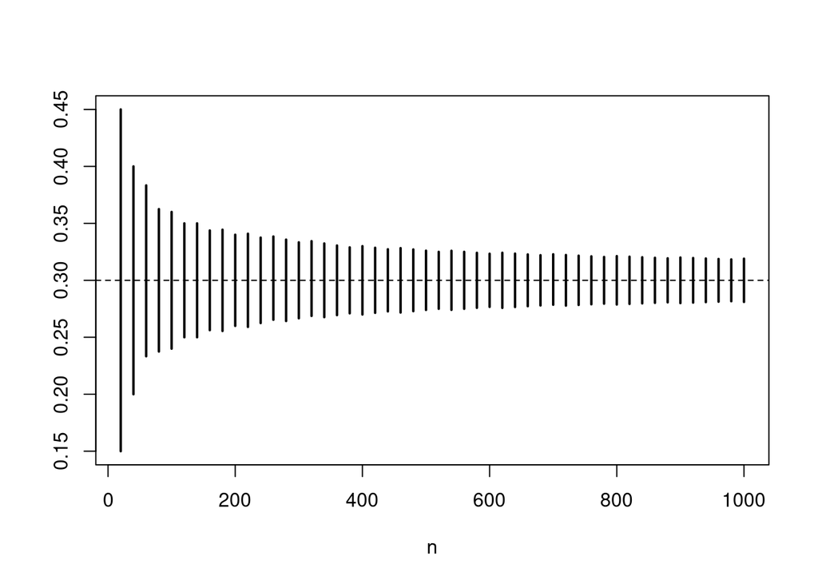

```r
p = 0.3
n = 20*(1:50)
L = qbinom(0.10, n, p)/n
U = qbinom(0.90, n, p)/n
plot(n, rep(p, length(n)), type = "n", ylim = c(min(L), max(U)), xlab="n", ylab = "")
segments(n, L, n, U, lwd = 2, col = "black")
abline(h = p, lty = 2)
```

- Where does this sequence converge to?
- Does the plot suggest such convergence? Change it into a logarithmic scale.

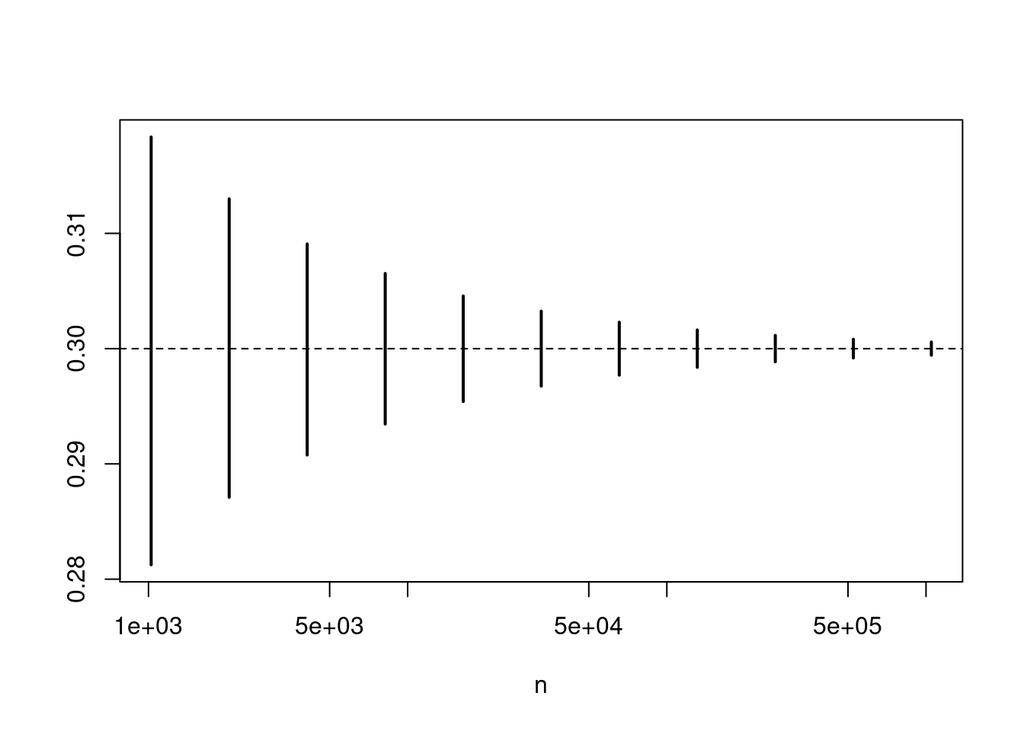

```r
n = 2^(10:20)
L = qbinom(0.10, n, p)/n
U = qbinom(0.90, n, p)/n
plot(n, rep(p, length(n)), log = "x", type = "n", ylim = c(min(L), max(U)), xlab="n", ylab = "")
segments(n, L, n, U, lwd = 2, col = "black")
abline(h = p, lty = 2)
```

## 1.2 The Central limit theorem

The Law of Large Numbers provides a first-order limit, which is deterministic: The sequence of partial means converges to the mean of the underlying distribution generating the random variables.

The Central Limit Theorem provides a second-order limit, which does not exist in a deterministic sence, but does in the distributional sense: The sequence of partial means, when standardized, converges in distribution to the standard normal distribution. (This assumes that the underlying distribution has finite second moment.)

To see this, we go back to the binomial example above, but we track down multiple quantiles of the successive (standardized) binomial distributions.

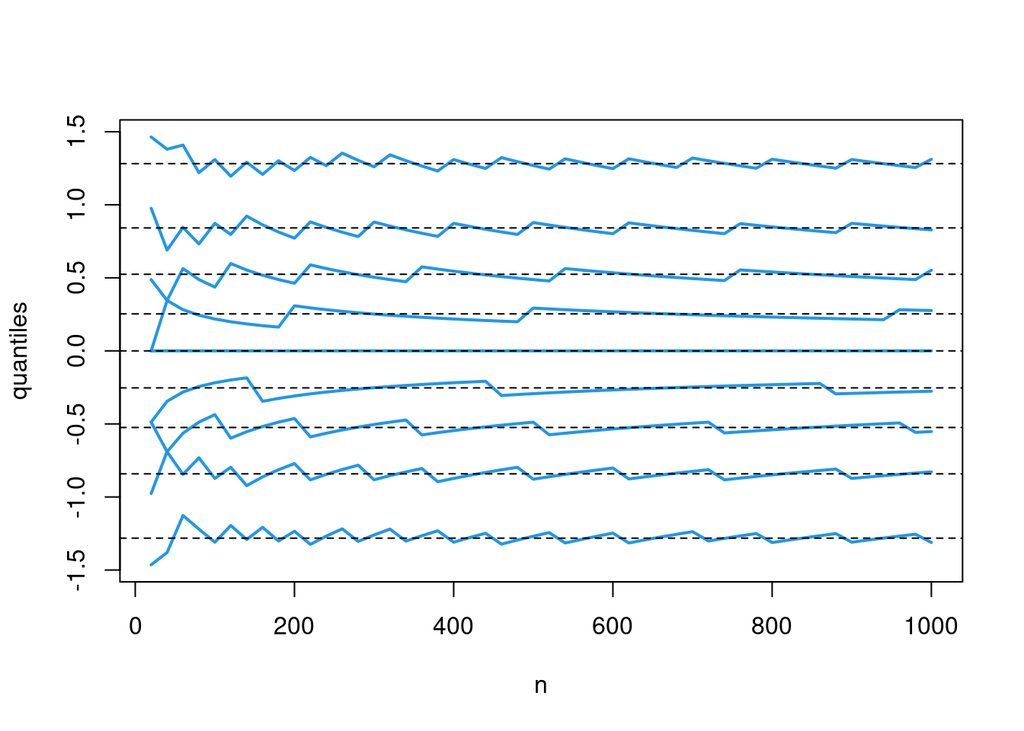

```r
p = 0.3
n = 20*(1:50)
Q = matrix(NA, 50, 9) # each row stores the quantiles of standardized binomial distribution
for (k in 1:50){
  Q[k, ] = (qbinom((1:9)/10, n[k], p) - n[k]*p)/sqrt(n[k]*p*(1-p))
}
matplot(n, Q, type = "l", lty = 1, lwd = 2, col = 4, xlab = "n", ylab = "quantiles")
abline(h = qnorm((1:9)/10), lty = 2) # quantiles of the standard normal distribution
```

### 1.2.1 The CLT and sampling distribution of the mean

A typical illustration of the CLT for the sample mean.

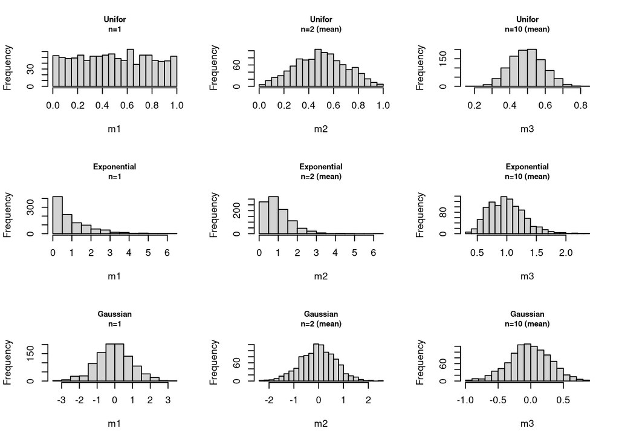

```r
datos<-list()
datos[[1]] <- matrix(runif(10000),nrow=1000)
datos[[2]] <- matrix(rexp(10000),nrow=1000)
datos[[3]] <- matrix(rnorm(10000),nrow=1000)
names(datos)<-c("Unifor","Exponential","Gaussian")
opt<-par(mfrow=c(3,3))
for (i in 1:3){
  x<-datos[[i]]
  m1<-x[,1]
  m2<-apply(x[,1:2],1,mean)
  m3<-apply(x,1,mean)
  hist(m1, 20, main=paste(names(datos)[i], "n=1", sep="\n"), cex.main=0.8);
  hist(m2, 20, main=paste(names(datos)[i], "n=2 (mean)", sep="\n"), cex.main=0.8)
  hist(m3, 20, main=paste(names(datos)[i], "n=10 (mean)", sep="\n"), cex.main=0.8)
}
```

Strictly speaking we are not illustrating the CLT here. What should we do for a better illustration?

# 2 The empirical distribution function

## 2.1 Building the empirical distribution function

- The empirical distribution function can be intuitively described through the following algorithm.
- Take a sample and consider it “fixed”
- Sort it
- consider values x that go from $-\infty$ to $\infty$ or, simply, from below the smallest number (e.g. $min(X_0)-1$) to above the highest value (e.g.$max(x_0)+1$).
  - Be sure to increase $x$ in such a way that the values in the sample will be “hit” by it,
- Build two vectors as followss:
  - $x_0=min(\mathbb{x_0})-1$
  - $y_0 = 0$
  - While $x_i< max(\mathbb{x_0})+1$ do
    - $x_i+1 = x_i+\Delta$
    - if $x_{i+1} \in \mathbb{x_0^{sorted}}$ then $y_{i+1}=y_i+\Delta$
- The values of $y$ form an approximation to the empirical cdf of $\mathbb{x_0}$

Implement an R function that generates the empirical distibution function given a sample.

R has a function implemented that computes the ecdf.º

```r
x0<-c(0.4,0.1,-0.6, 1.8,0.5,-2.0, 0.7, -0.5, -1.1, -0.2, -1.0, -0.7)
Fn <- ecdf(x0)
Fn(x0)
```

```
##  [1] 0.75000000 0.66666667 0.41666667 1.00000000 0.83333333 0.08333333
##  [7] 0.91666667 0.50000000 0.16666667 0.58333333 0.25000000 0.33333333
```

```r
summary(Fn)
```

```
## Empirical CDF:     12 unique values with summary
##    Min. 1st Qu.  Median    Mean 3rd Qu.    Max.
## -2.0000 -0.7750 -0.3500 -0.2167  0.4250  1.8000
```

```r
knots(Fn)
```

```
##  [1] -2.0 -1.1 -1.0 -0.7 -0.6 -0.5 -0.2  0.1  0.4  0.5  0.7  1.8
```

```r
sort(unique(Fn(x0)))
```

```
##  [1] 0.08333333 0.16666667 0.25000000 0.33333333 0.41666667 0.50000000
##  [7] 0.58333333 0.66666667 0.75000000 0.83333333 0.91666667 1.00000000
```

## 2.2 Ploting the empirical cdf with R

Functions `ecdf` and `plot.ecdf` facilitate the visualization of the empirical cdf.

```r
op <- par(mfrow=c(3,1), mgp=c(1.5, 0.8,0), mar= .1+c(3,3,2,1))

set.seed(123)
x0 <- round(rnorm(12),3)
x0
```

```
##  [1] -0.560 -0.230  1.559  0.071  0.129  1.715  0.461 -1.265 -0.687 -0.446
## [11]  1.224  0.360
```

```r
Fn12 <- ecdf(x0)
summary(Fn12)
```

```
## Empirical CDF:     12 unique values with summary
##    Min. 1st Qu.  Median    Mean 3rd Qu.    Max.
## -1.2650 -0.4745  0.1000  0.1943  0.6518  1.7150
```

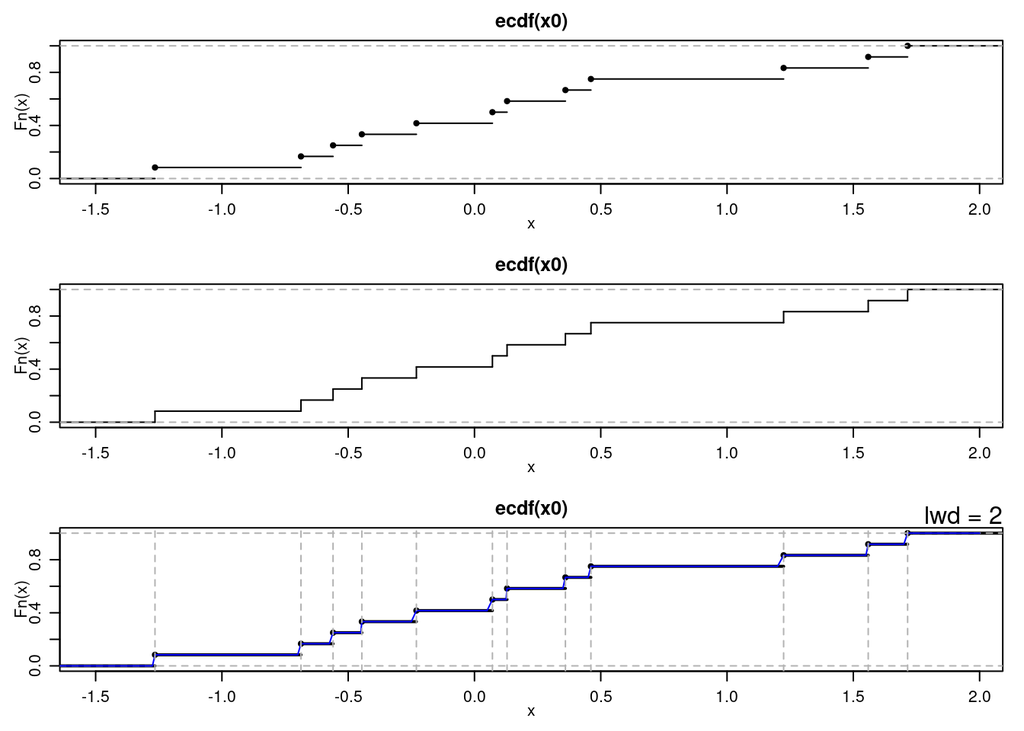

```r
plot(Fn12)
plot(Fn12, verticals= TRUE, do.points = FALSE)

plot(Fn12 , lwd = 2) ; mtext("lwd = 2", adj=1)
xx <- unique(sort(c(seq(-3, 2, length=201), knots(Fn12))))
lines(xx, Fn12(xx), col='blue')
abline(v=knots(Fn12),lty=2,col='gray70')
```

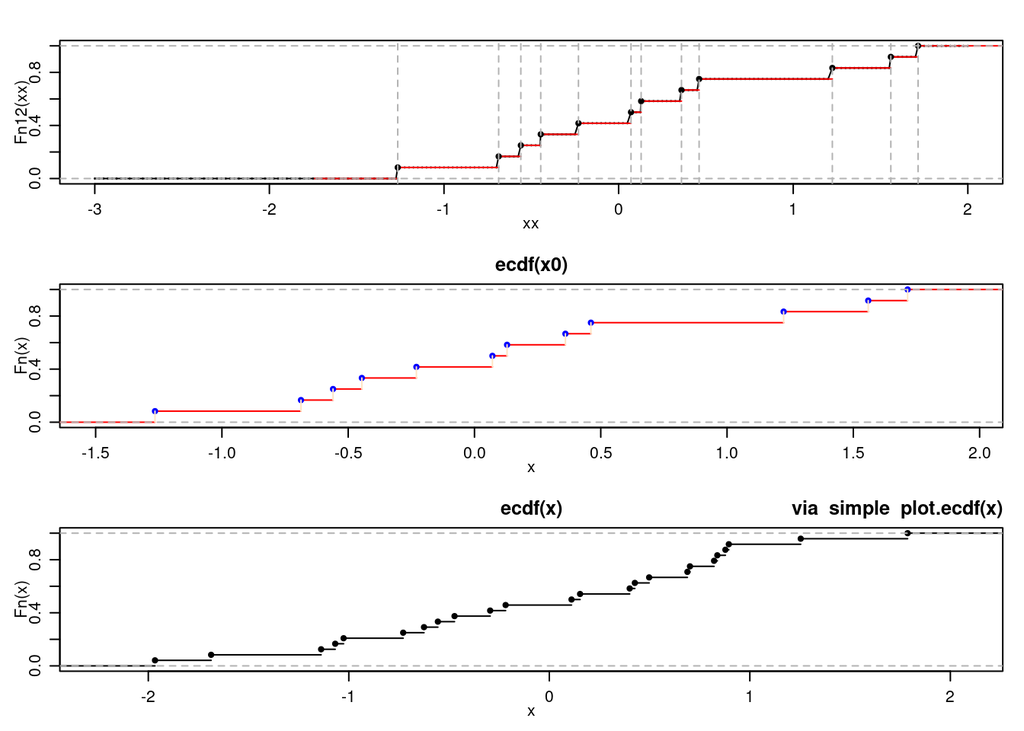

```r
plot(xx, Fn12(xx), type='o', cex=.1)#- plot.default {ugly}
plot(Fn12, col.hor='red', add= TRUE)  #- plot method
abline(v=knots(Fn12),lty=2,col='gray70')
## luxury plot
plot(Fn12, verticals=TRUE, col.points='blue',
     col.hor='red', col.vert='bisque')

##-- this works too (automatic call to  ecdf(.)):
plot.ecdf(rnorm(24))
title("via  simple  plot.ecdf(x)", adj=1)
```

```r
par(op)
```

## 2.3 Showing that $F_n()$ approximates $F()$

For the normal distribution

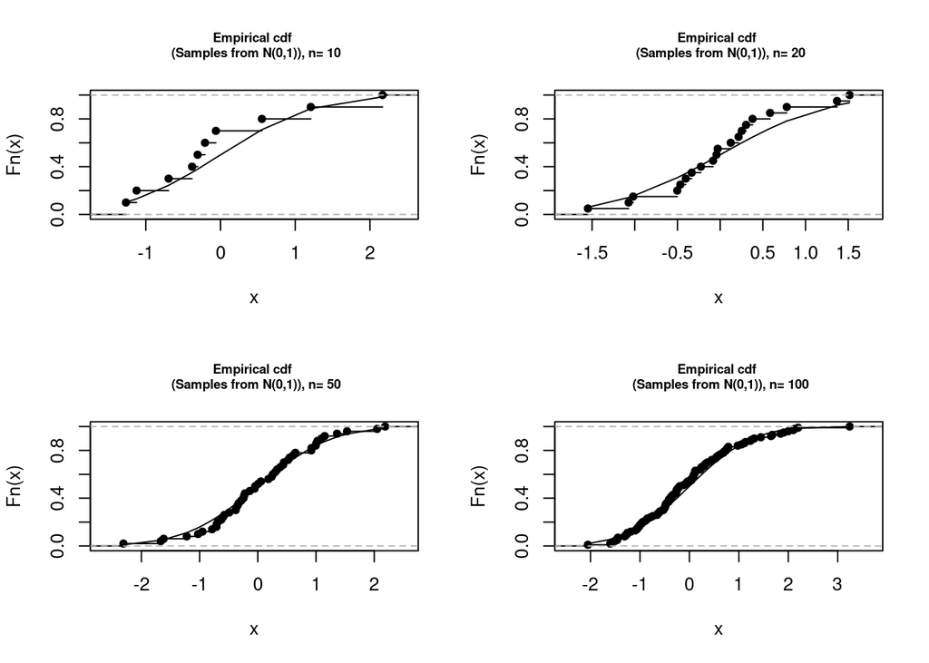

```r
op<-par(mfrow=c(2,2))
for(n in c(10, 20, 50, 100)){
  x<- sort(rnorm(n))
  plot.ecdf(x, main=paste ("Empirical cdf \n (Samples from N(0,1)), n=", n), cex.main=0.7)
  tcdf<- pnorm(x)
  lines(x,tcdf)
 }
```

```r
par(op)
```

Or the uniform distribution

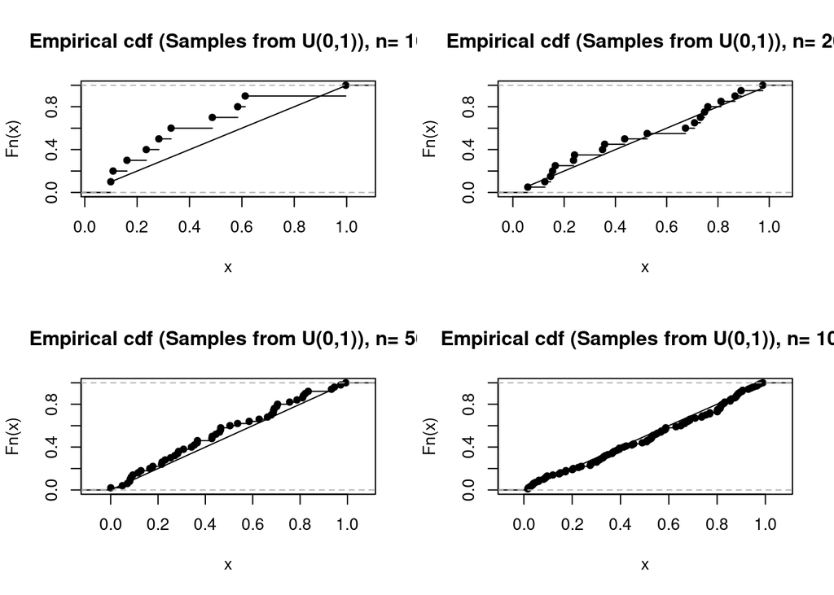

```r
op<-par(mfrow=c(2,2))
for(n in c(10, 20, 50, 100)){
  x<- sort(runif(n))
  plot.ecdf(x, main=paste ("Empirical cdf (Samples from U(0,1)), n=", n))
  tcdf<- punif(x)
  lines(x,tcdf)
 }
```

# 3 The bootstrap

## 3.1 Basic resampling (i): Standard error of the mean

```r
# Asignación de los datos a un vector
x <- c(94,197,16,38,99,141,23)
#Calculo de la media y de su error estandar
theta <- mean(x)
stderrtheta <- sqrt(var (x)/length(x))
#Visualizacion de la media y de su error estandar
cat("theta = " , theta,"\n")
```

```
## theta =  86.85714
```

```r
cat("Error estandard de theta = " , stderrtheta,"\n")
```

```
## Error estandard de theta =  25.23549
```

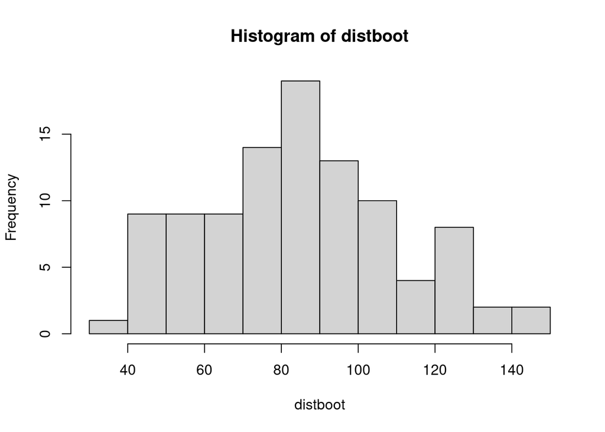

```r
# Preparacion del remuestreo
# Numero de remuestras
nboot<-100
# Creación de un vector en donde guardar las remuestras
distboot<- rep(NA,nboot)
# Remuestreo
for (b in 1:nboot)
   {x.boot<-sample(x,replace=T)
    distboot[b] <-mean (x.boot)
}
hist(distboot)
```

```r
# Error estandar bootstrap
stderrboot <-sqrt(var(distboot))
#Visualizacion del error estandar bootstrap
cat("Error estandard bootstrap= " , stderrboot,"\n")
```

```
## Error estandard bootstrap=  24.80987
```

```r
# Distribucion bootstrap
results<-summary(distboot)
print(results)
```

```
##    Min. 1st Qu.  Median    Mean 3rd Qu.    Max.
##   36.43   67.43   85.36   85.13  100.61  143.57
```

```r
bootstrapsSeMean <- function(x, B){
 res <- numeric(B)
 for(i in 1:B)
 res[i] <- mean(sample(x, replace=TRUE))
 res <- sd(res)
 return(res)
}
x <- c(94,197,16,38,99,141,23)
bootstrapsSeMean (x, 100)
```

```
## [1] 23.19016
```

## 3.2 Basic resampling (ii): Standard error of the median

```r
bootstrapSeMedian <- function(x, B){
  res <- numeric(B)
  for(i in 1:B)
     res[i] <- median(sample(x, replace=TRUE))
     res <- sd(res)
     return(res)
}
bootstrapSeMedian(x, 1000)
```

```
## [1] 38.83399
```

## 3.3 The bootstrap distribution

The histogram of all estimations computed on all the resamples is an approximation to the *bootstrap* distribution of the statistic.

```r
if (!require(bootstrap)) install.packages("bootstrap", dep=TRUE)
library(bootstrap)
data('law')

set.seed(1)
theta <- function(ind) {
  cor(law[ind, 1], law[ind, 2], method = "pearson")
}

theta0 <- cor(law$LSAT, law$GPA)

# for(b in 1:5){
#   indiv<- sample(1:15, replace=TRUE)
#   show(t(resample <- law[indiv,]))
#   show(cor(resample)[1,2])
# }
law.boot <- bootstrap(1:15, 1000, theta)
summary(law.boot)
```

```
##                Length Class  Mode
## thetastar      1000   -none- numeric
## func.thetastar    0   -none- NULL
## jack.boot.val     0   -none- NULL
## jack.boot.se      0   -none- NULL
## call              4   -none- call
```

An approximation to the bootstrap distribution.

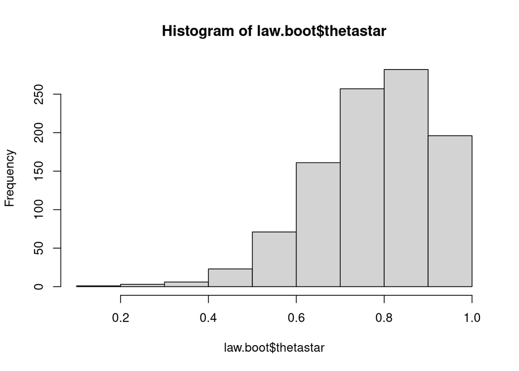

```r
hist(law.boot$thetastar)
```

## 3.4 Bootstrap confidence intervals

There are many ways to use the bootstrap to compute confidence intervals.

The simplest one is assuming normality of the estimator and uise the standard error to build normal confidence intervals:

```r
ci1 <- qnorm(p=c(.025, .975),
            mean=theta0,
            sd=sd(law.boot$thetastar))
ci1
```

```
## [1] 0.5156287 1.0371203
```

The *bootstrap percentile* method relies on the quantiles of the bootstrap distribution-

```r
quantile(law.boot$thetastar, c(0.025, 0.975))
```

```
##      2.5%     97.5%
## 0.4816260 0.9648576
```

For improved estimators it is preferable to use built-in functions such as those available in packages `boot` or `bootstrap`

See for example

https://www.rdocumentation.org/packages/resample/versions/0.4/topics/CI.percentile

## 3.5 Bootstraping a multivariate data set (Exercise U-2-I-9)

File `scores5.dat` contains the scores in 5 topics of 88 U.B. students.

1. This data matrix has a $5 \times 5$ variance-covariance matrix with positive eigenvalues $\lambda_{1} >\lambda_{1} > \lambda_{2} > ... > \lambda_{5}$. Let $\theta$ be:
   $$\theta= \dfrac{\lambda_{1}} {\sum_{i=1}^{n} \lambda_{i}}.$$

$\theta$ is used to represent the percentage of variability explained by the first principal component.

Let $\hat{\lambda_{1}} >\hat{\lambda_{2}} > ... > \hat{\lambda_{5}}$ be the eigenvalues of $\widehat{\sum}$, the MLE of $\sum$. From here, by the functional invariance principle of the MLE one has:
$$\hat{\theta}= \dfrac{\hat{\lambda_{1}}} {\sum_{i=1}^{n} \hat{\lambda_{i}}}$$

### 3.5.1 Describe how can one resample the data matrix to obtain an approximation of the bootstrap distribution of $\hat{\theta}$. Using the process derived above compute a bootstrap estimate of the standard error of $\hat{\theta}$.

This is an scenario in which each observation is a multivariate random vector of five components, which corresponds to each row of the data matrix.

Resampling from the empirical distribution means resampling the data matrix **by rows**, in order to maintain each original observation.

A bootstrap sample of the data matrix X would be a matrix $X_B$ with the same dimensions than X whose rows would be randomly sampled with replacement from the rows of $X$.

```r
datamatrix<-read.delim("scores5.dat")
covmatrix<-cov(datamatrix)
ev<-eigen(covmatrix)
evalues<-ev$values
theta <- evalues[1]/sum(evalues); theta
```

```
## [1] 0.7300532
```

```r
set.seed(2)
n<-1000
distboot<- rep(NA,n)

for (i in 1:n){
  bootindexes <- sample ( nrow ( datamatrix ),replace = TRUE )
  bootmatrix <- datamatrix [ bootindexes ,]
  covmatrix1<-cov(bootmatrix)
  ev1<-eigen(covmatrix1)
  evalues1<-ev1$values
  distboot[i] <-evalues1[1]/sum(evalues1)
}

stderrboot <-sqrt(var(distboot)); stderrboot
```

```
## [1] 0.04159342
```

### 3.5.2 Provide a bias corrected estimate of $\theta$.

The bias of an estimator is defined as
$$b(\hat \theta) = E(\hat \theta)- \theta.$$
Bias can be estimated using the bootstrap as folllows: Thinling of the equivalence of “roles” between real world and bootstrap world we can set

- The role of $\theta$ is played by $\hat \theta$
- The role of $E(\hat \theta)$ is played by $\widehat{E_B(\hat \theta)}$.
- The bootstrap bias estimate is then
  $$b_B(\hat \theta) = \widehat{E_B(\hat \theta)}- \hat \theta.$$

And the bias corrected estimate of $\theta$ is

$$\hat \theta_{BC} = \hat \theta -b_B(\hat \theta) =
2 \hat \theta- \widehat{E_B(\hat \theta)}.$$

Finally recall that although these should be exact bootstrap estimates, they can be approximated using Monte Carlo resampling and taking the mean of the resampled vvalues.

$$\widehat{E_B(\hat \theta)} \simeq \frac 1B \sum_{b=1}^B \hat \theta^b$$
In our example we would simply do:

```r
Etheta <- mean(distboot);Etheta
```

```
## [1] 0.7288113
```

```r
theta <- evalues[1]/sum(evalues);theta
```

```
## [1] 0.7300532
```

```r
btheta<- Etheta - theta; btheta
```

```
## [1] -0.001241937
```

```r
thetaCB <- 2 *theta - Etheta; thetaCB
```

```
## [1] 0.7312951
```

Notice that **all results are very similar**. That is in spite of how “reasonable” the approach may seem we may need some theoretical results or some simluation analysis to decide up to what point the bias adjustment improves the estimator.

# 4 Introducing permutation tests

One of the most common problems with statistical inference is not being able to verify some assumptions of the assumed model for the data, such as normality.

In these cases, it is usual to consider different alternatives such as non-parametric tests, (which is usually labeled as having little power) or permutations tests.

```r
# Do not have the image locally on my machine.
#knitr::include_graphics("images/permutationtests.jpg")
```

## 4.1 Example

We You want to compare the mean survival time in weeks of two groups of mice affected by liver disease that have been treated with a drug ($z$) or a placebo ($y$).

- Implement a permutation test as described above to compare the means of the two groups, using a two-sample t-statistic as a test statistic.
- Apply the implemented test to compare the obtained values. Base the estimate of the p-value on 10,000 random permutations.
- In case you don’t want to use a permutation test, what would be an alternative reasonable approach?
- Compare the results obtained with the alternative suggested with those of the permutation tests. Which one do you think is more appropriate in this case? What are the advantages or disadvantages of each of them?

### 4.1.1 Building a permutations distribution

```r
tr <- c( 94, 197, 16, 38, 99, 141, 23)
y <- c( 52, 104, 146, 10, 51, 30, 40, 27, 46)
testInSample<- mean(tr) - mean(y)
```

To obtain a single permutation of the data, we combine the data and then sample without replacement two “mock” tr and y vectors.

```r
testFun<- function(x1,x2){
  mean(x2)-mean(x1)
}
nt<- length(tr)
ny<- length(y)
N<- nt+ny
s <- sample(c(tr, y), N, FALSE)
trp <- s[1:nt]
yp <- s[(nt+1):N]
testFun(yp, trp)
```

```
## [1] 10.06349
```

If we repeat this process a large number of times, we can build our approximate permutation distribution (i.e., the sampling distribution for the mean-difference).

The result will be a vector of the differences from each permutation (i.e., our distribution):

```r
NPerm <- 2000
testValues <- numeric(NPerm)
for (i in 1:NPerm){
  permutedS<- sample(s, N, FALSE)
  trp <- permutedS[1:nt]
  yp <- permutedS[(nt+1):N]
  testValues[i]<- testFun(yp, trp)
}
summary(testValues)
```

```
##     Min.  1st Qu.   Median     Mean  3rd Qu.     Max.
## -75.0159 -18.6349   0.4127   1.2176  21.4921  86.2540
```

We can look at our distribution using hist and draw a vertical line for our observed difference:

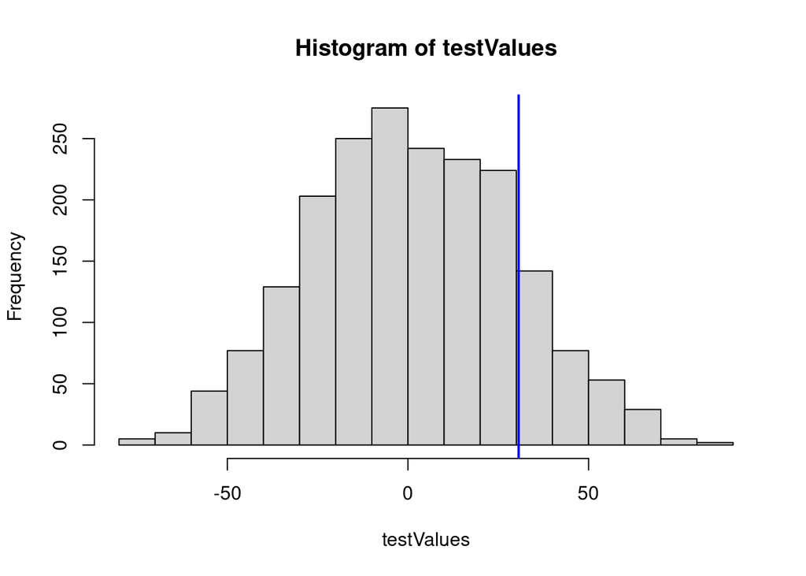

```r
par(mfrow=c(1,1))
hist(testValues)
abline(v = testInSample, col = "blue", lwd = 2)
```